# DS-University-Enrolment

Matthew Adenyo

2023-09-16

# Background

You are working as a data scientist at a local University. The university started offering online courses to reach a wider range of students. The university wants you to help them understand enrollment trends. They would like you to identify what contributes to higher enrollment. In particular, whether the course type (online or classroom) is a factor.

The dataset contains records for each course offered over the last 5 years.

```r
#Load required libraries
library(readr)
library(ggplot2)
library(caret)
library(dplyr)
library(tidyr)
library(glmnet)
library(lattice)
library(e1071)
```

```r
#Read datasets
data <- read.csv("D:/Data Science Projects/DS-Associate-Certification/Data/university_enrollment_2306.csv")
```

```r
# Display data summary
str(data)
```

```
## 'data.frame':    1850 obs. of  8 variables:
##  $ course_id       : int  1 2 3 4 5 6 7 8 9 10 ...
##  $ course_type     : chr  "classroom" "classroom" "online" "online" ...
##  $ year            : int  2018 2020 2016 2013 2019 2014 2021 2018 2019 2016 ...
##  $ enrollment_count: int  165 175 257 251 165 246 241 261 261 180 ...
##  $ pre_score       : chr  "28.14" "79.68" "57.24" "97.67" ...
##  $ post_score      : int  73 86 80 75 76 76 84 88 87 79 ...
##  $ pre_requirement : chr  "Beginner" "None" NA "Beginner" ...
##  $ department      : chr  "Science" "Science" "Mathematics" "Technology" ...
```

```r
dim(data)
```

```
## [1] 1850    8
```

```r
sapply(data, class)
```

```
##        course_id      course_type             year enrollment_count
##        "integer"      "character"        "integer"        "integer"
##        pre_score       post_score  pre_requirement       department
##      "character"        "integer"      "character"      "character"
```

```r
summary(data)
```

```
##    course_id      course_type             year      enrollment_count
##  Min.   :   1.0   Length:1850        Min.   :2011   Min.   :154.0
##  1st Qu.: 463.2   Class :character   1st Qu.:2013   1st Qu.:185.0
##  Median : 925.5   Mode  :character   Median :2016   Median :251.0
##  Mean   : 925.5                      Mean   :2016   Mean   :231.6
##  3rd Qu.:1387.8                      3rd Qu.:2019   3rd Qu.:261.0
##  Max.   :1850.0                      Max.   :2022   Max.   :267.0
##
##   pre_score           post_score    pre_requirement     department
##  Length:1850        Min.   : 51.0   Length:1850        Length:1850
##  Class :character   1st Qu.: 69.0   Class :character   Class :character
##  Mode  :character   Median : 75.0   Mode  :character   Mode  :character
##                     Mean   : 75.2
##                     3rd Qu.: 81.0
##                     Max.   :105.0
##                     NA's   :185
```

# Task 1:

## For every column in the data:

### a. State whether the values match the description given in the table above.

### b. State the number of missing values in the column.

### c. Describe what you did to make values match the description if they did not match.

```r
# Compare the description for each column

# course_id Data Validation
unique_id <- length(unique(data$course_id)) == nrow(data)
course_count_na <- sum(is.na(data$course_id))

cat("----- course_id -----\n")
```

```
## ----- course_id -----
```

```r
cat(paste("Column 'course_id' has only unique values:", ifelse(unique_id, "TRUE", "FALSE"), "\n"))
```

```
## Column 'course_id' has only unique values: TRUE
```

```r
cat(paste("Sum of missing values:", course_count_na, "\n\n"))
```

```
## Sum of missing values: 0
```

```r
# course_type Data Validation
online_class <- unique(data$course_type)
course_type_count_na <- sum(is.na(data$course_type))

cat("----- course_type -----\n")
```

```
## ----- course_type -----
```

```r
cat("Values in this column:\n", online_class, "\n")
```

```
## Values in this column:
##  classroom online
```

```r
cat(paste("Sum of missing values:", course_type_count_na, "\n\n"))
```

```
## Sum of missing values: 0
```

```r
# year Data Validation
years <- unique(data$year)
year_count_na <- sum(is.na(data$year))

cat("----- year -----\n")
```

```
## ----- year -----
```

```r
cat("Values in this column:\n", years, "\n")
```

```
## Values in this column:
##  2018 2020 2016 2013 2019 2014 2021 2022 2011 2015 2012 2017
```

```r
cat(paste("Sum of missing values:", year_count_na, "\n\n"))
```

```
## Sum of missing values: 0
```

```r
# enrollment_count Data Validation
enrollment_count_na <- sum(is.na(data$enrollment_count))

cat("----- enrollment_count -----\n")
```

```
## ----- enrollment_count -----
```

```r
cat("Description of values in this column:\n")
```

```
## Description of values in this column:
```

```r
summary(data$enrollment_count)
```

```
##    Min. 1st Qu.  Median    Mean 3rd Qu.    Max.
##   154.0   185.0   251.0   231.6   261.0   267.0
```

```r
cat(paste("Sum of missing values:", enrollment_count_na, "\n\n"))
```

```
## Sum of missing values: 0
```

```r
# pre_score Data Validation
# Replace non-numeric values with NA
data$pre_score[data$pre_score == "-"] <- NA
pre_score_count_na <- sum(is.na(data$pre_score))

cat("----- pre_score -----\n")
```

```
## ----- pre_score -----
```

```r
cat("Description of values in this column:\n")
```

```
## Description of values in this column:
```

```r
summary(as.numeric(data$pre_score))
```

```
##    Min. 1st Qu.  Median    Mean 3rd Qu.    Max.    NA's
##    1.02   24.08   48.91   49.53   75.06  100.00     130
```

```r
cat(paste("Sum of missing values before cleaning:", pre_score_count_na, "\n\n"))
```

```
## Sum of missing values before cleaning: 130
```

```r
# post_score Data Validation
post_score_count_na <- sum(is.na(data$post_score))

cat("----- post_score -----\n")
```

```
## ----- post_score -----
```

```r
cat("Description of values in this column:\n")
```

```
## Description of values in this column:
```

```r
summary(data$post_score)
```

```
##    Min. 1st Qu.  Median    Mean 3rd Qu.    Max.    NA's
##    51.0    69.0    75.0    75.2    81.0   105.0     185
```

```r
cat(paste("Sum of missing values before cleaning:", post_score_count_na, "\n\n"))
```

```
## Sum of missing values before cleaning: 185
```

```r
# pre_requirement Data Validation
pre_req <- unique(data$pre_requirement)
pre_req_count_na <- sum(is.na(data$pre_requirement))

cat("----- pre_requirement -----\n")
```

```
## ----- pre_requirement -----
```

```r
cat("Values in this column:", pre_req, "\n")
```

```
## Values in this column: Beginner None NA Intermediate
```

```r
cat(paste("Sum of missing values before cleaning:", pre_req_count_na, "\n\n"))
```

```
## Sum of missing values before cleaning: 89
```

```r
# department Data Validation
dep <- unique(data$department)
dep_count_na <- sum(is.na(data$department))

cat("----- department -----\n")
```

```
## ----- department -----
```

```r
cat("Values in this column:\n", dep, "\n")
```

```
## Values in this column:
##  Science Mathematics Technology Math Engineering
```

```r
cat(paste("Sum of missing values before cleaning:", dep_count_na, "\n\n"))
```

```
## Sum of missing values before cleaning: 0
```

```r
# Data Cleaning
cat("For each column that presented missing values, or incorrect description:\n")
```

```
## For each column that presented missing values, or incorrect description:
```

```r
# pre_score - replace missing values and "-"
data$pre_score[is.na(data$pre_score) | data$pre_score == "-"] <- 0
pre_score_count_na <- sum(is.na(data$pre_score))
cat("----- pre_score -----\n")
```

```
## ----- pre_score -----
```

```r
cat(paste("Sum of missing values after cleaning:", pre_score_count_na, "\n\n"))
```

```
## Sum of missing values after cleaning: 0
```

```r
# post_score - replace missing values and "-"
data$post_score[is.na(data$post_score) | data$post_score == "-"] <- 0
post_score_count_na <- sum(is.na(data$post_score))
cat("----- post_score -----\n")
```

```
## ----- post_score -----
```

```r
cat(paste("Sum of missing values after cleaning:", post_score_count_na, "\n\n"))
```

```
## Sum of missing values after cleaning: 0
```

```r
# pre_requirement - replace missing values and "-"
data$pre_requirement[is.na(data$pre_requirement) | data$pre_requirement == "-"] <- "None"
pre_req_count_na <- sum(is.na(data$pre_requirement))
cat("----- pre_requirement -----\n")
```

```
## ----- pre_requirement -----
```

```r
cat(paste("Sum of missing values after cleaning:", pre_req_count_na), "\n")
```

```
## Sum of missing values after cleaning: 0
```

```r
cat(paste("Unique values after cleaning:", unique(data$pre_requirement), "\n\n"))
```

```
## Unique values after cleaning: Beginner
##
##  Unique values after cleaning: None
##
##  Unique values after cleaning: Intermediate
```

```r
# department - replace "Math" values with "Mathematics"
data$department <- ifelse(data$department == "Math", "Mathematics", data$department)
cat("----- department -----\n")
```

```
## ----- department -----
```

```r
cat(paste("Unique values after cleaning:", unique(data$department), "\n"))
```

```
## Unique values after cleaning: Science
##  Unique values after cleaning: Mathematics
##  Unique values after cleaning: Technology
##  Unique values after cleaning: Engineering
```

**Solution To Task 1:**

The dataset contains **1850 rows and 8 columns** with missing values before cleaning. All the columns were validated against the criteria in the dataset table. Below were the observations:

- Column 1 (course_id): Matches the description as unique identifier with 0 missing values.
- Column 2 (course_type): All values are either “online” or “classroom” with 0 missing values.
- Column 3 (year): All values are between 2011 and 2022 inclusive with 0 missing values.
- Column 4 (enrollment_count): All values are discrete counts of enrollments with 0 missing values.
- Column 5 (pre_score): Contains continuous score data with **130 missing values**. Missing values were replaced with 0.
- Column 6 (post_score): Contains continuous score data with **185 missing values**. Missing values were replaced with 0.
- Column 7 (pre_requirement): All values are either “None”, “Beginner” or “Intermediate” with **89 missing values**. Missing values were replaced with “None”.
- Column 8 (department): The values here are either “Science”, “Technology”, “Engineering”, or “Mathematics”, however, there were instances of *“Math”* which is not in the given criteria. It is assumed that “Math” refers to “Mathematics” and were replaced accordingly.

# Task 2:

## Describe the distribution of the enrollment counts. Your answer must include a visualization that shows the distribution.

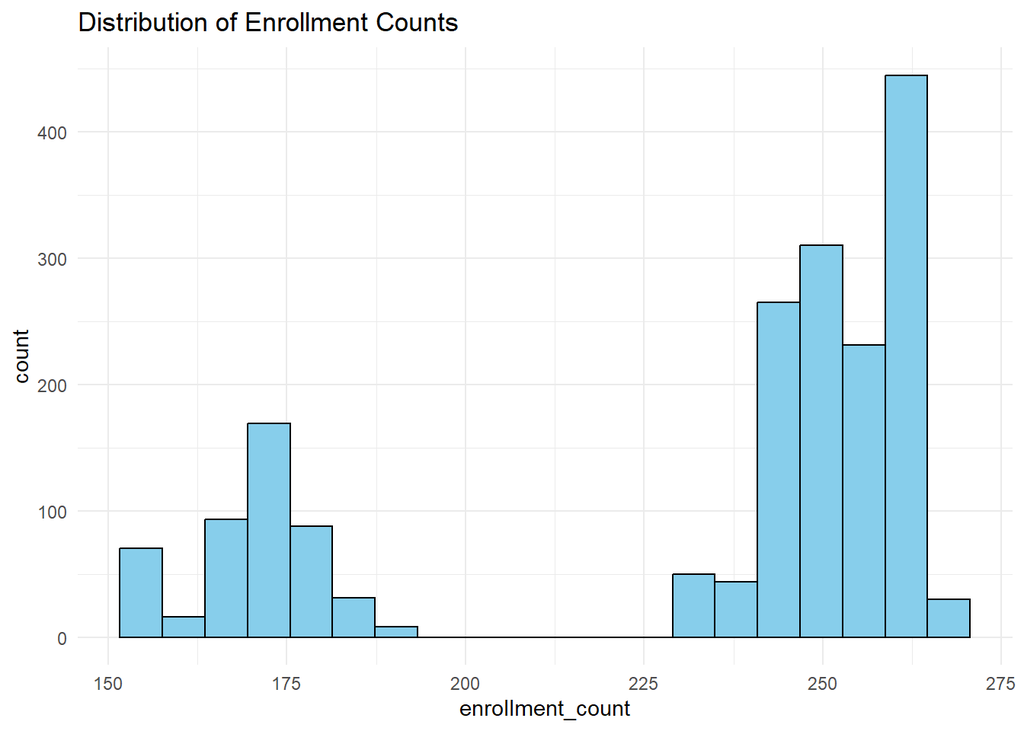

```r
# Creating subplots
par(mfrow=c(1, 2), mar=c(4, 4, 2, 1))

# Distribution of Enrollment Count
ggplot(data, aes(x = enrollment_count)) +
  geom_histogram(bins = 20, fill = "skyblue", color = "black") +
 # geom_density(alpha = 0.5, color = "red") +
  labs(title = "Distribution of Enrollment Counts") +
  theme_minimal()
```

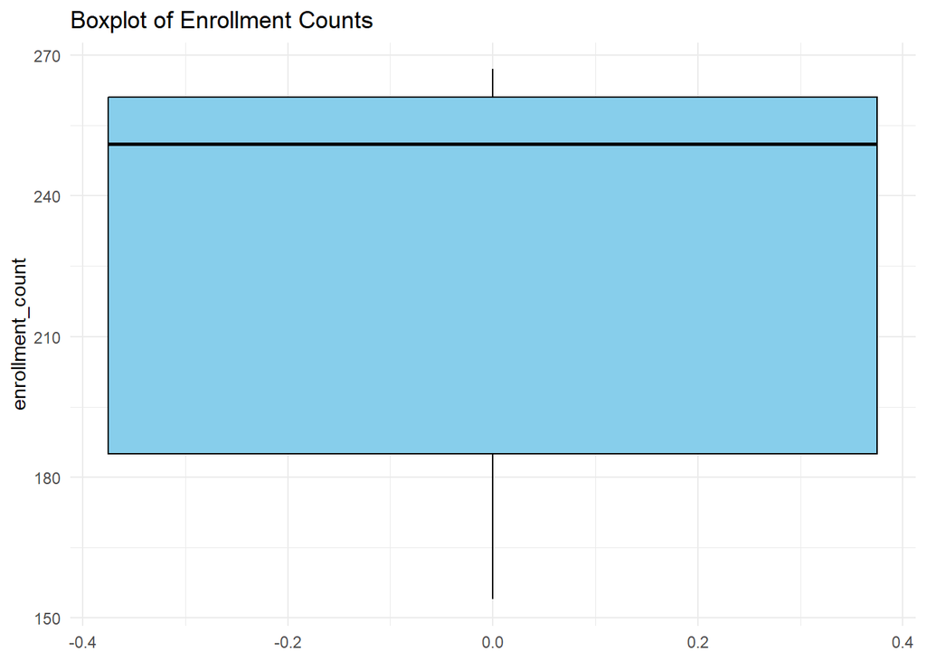

```r
# Boxplot of Enrollment Count
ggplot(data, aes(y = enrollment_count)) +
  geom_boxplot(fill = "skyblue", color = "black") +
  labs(title = "Boxplot of Enrollment Counts") +
  theme_minimal()
```

```r
# Reset the plotting layout
par(mfrow=c(1, 1))

# Calculate important metrics
mean_val <- mean(data$enrollment_count)
median_val <- median(data$enrollment_count)
mode_val <- as.numeric(names(table(data$enrollment_count))[table(data$enrollment_count)
                                                           == max(table(data$enrollment_count))])

cat(paste("- Mean:", mean_val, "\n"))
```

```
## - Mean: 231.565405405405
```

```r
cat(paste("- Median:", median_val, "\n"))
```

```
## - Median: 251
```

```r
cat(paste("- Mode:", mode_val, "\n"))
```

```
## - Mode: 261
```

**Solution To Task 2:**

From Graph, it can be seen that the graph is divided into two distinct groups. This indicates two discernible clusters along the x-axis of which the most prominent is around the region of 260 enrollments. This suggests that the majority of the enrollment counts happens around this area, as confirmed by the mode value of 261 and median value of 251. The histogram also reveals that some courses have far less enrollments at the region of 170, which could be due to ineffective marketing strategies, lack of interest in the courses, or even data entry errors. It would be good to further investigate the factors contributing to this low enrollment count.

# Task 3:

## Create a visualization that shows how many courses were of each type. Use the visualization to:

### a. State which type of course has the most observations.

### b. Explain whether the observations are balanced across the types.

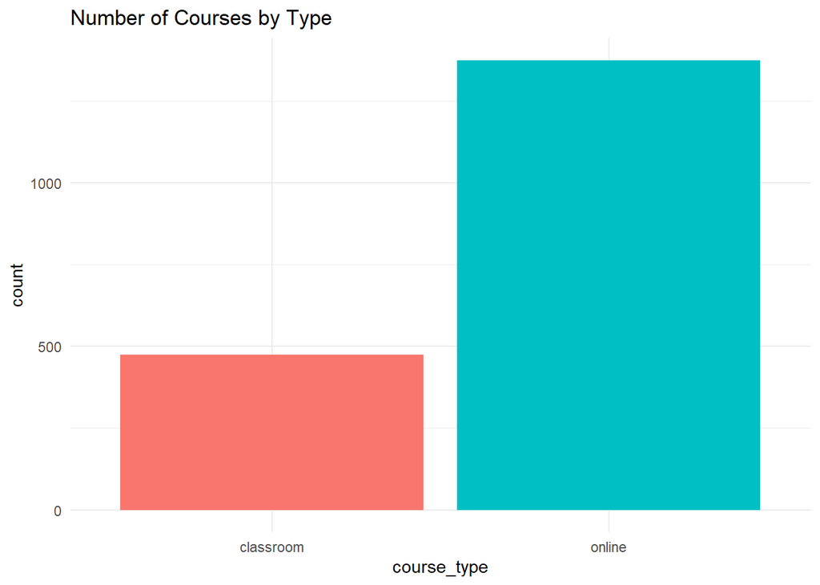

```r
#Bar plot to Visualize the Course type
ggplot(data, aes(x = course_type, fill = course_type)) +
  geom_bar() +
  labs(title = "Number of Courses by Type") +
  theme_minimal() +
  theme(legend.position = "none")
```

```r
# Calculate and print the proportion
classroom <- sum(data$course_type == "classroom")
online <- nrow(data) - classroom
proportion <- round((online / (online + classroom)) * 100)

cat(paste("- Proportion of Online to Classroom Type of Courses:", proportion, "%\n"))
```

```
## - Proportion of Online to Classroom Type of Courses: 74 %
```

**Solution To Task 3:**

- 1. From the graph, online has the most observations.
- 2. The observations are not balanced across the two types of courses. Online courses make up approximately 74% of the total leaving only 26% for classroom courses. The is a disproportion in the course type which may potentially impact the results of the model by over representing online courses. This can be solve by data manipulation techniques to balance the proportions, however, as a result of this analysis, the current distribution is maintained.

# Task 4:

## Describe the relationship between course type and the enrollment count. Your answer must include a visualization to demonstrate the relationship.

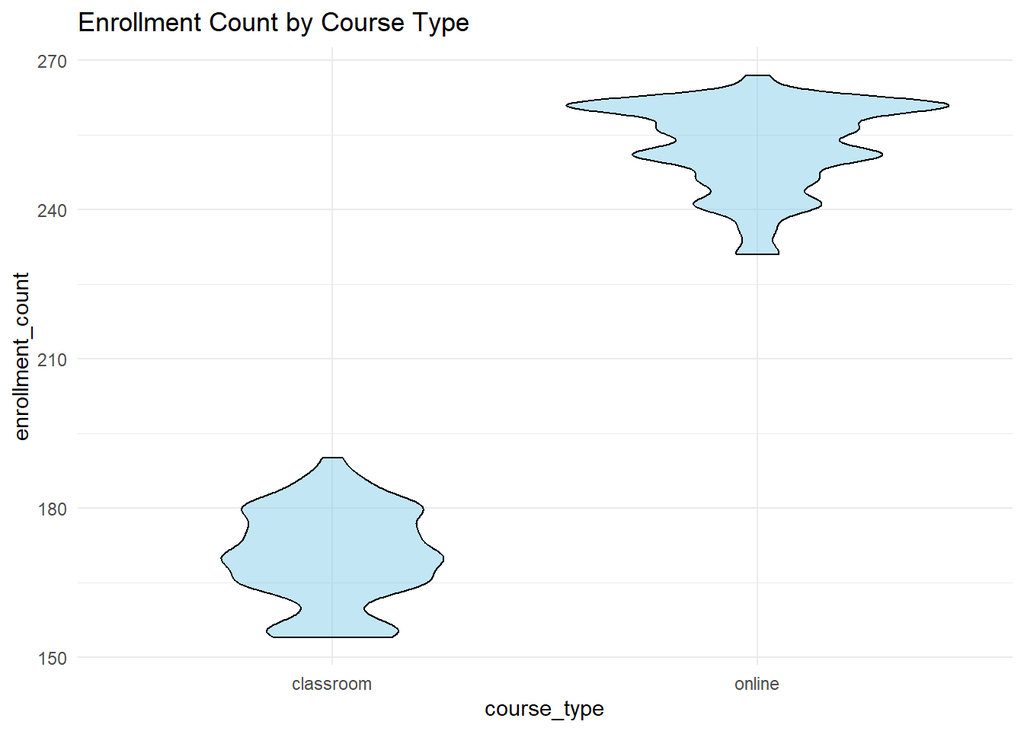

```r
# Violin plot
ggplot(data, aes(x = course_type, y = enrollment_count)) +
  geom_violin(fill = "skyblue", color = "black", alpha = 0.5) +
  labs(title = "Enrollment Count by Course Type") +
  theme_minimal()
```

```r
# Calculate and print the means
classroom <- round(mean(data[data$course_type == "classroom", "enrollment_count"], na.rm = TRUE))
online <- round(mean(data[data$course_type == "online", "enrollment_count"], na.rm = TRUE))

cat(paste("- Avg. enrollment count for Classroom Courses:", format(classroom, big.mark = ","), "\n"))
```

```
## - Avg. enrollment count for Classroom Courses: 170
```

```r
cat(paste("- Avg. enrollment count for Online Courses:", format(online, big.mark = ","), "\n"))
```

```
## - Avg. enrollment count for Online Courses: 253
```

**Solution To Task 4:**

The graph above reveals a clear difference between the number of enrollments in the online and the classroom courses. Online courses outnumber classroom courses in terms of availability and also to attract a larger number of students. The average enrollment for online courses is approximately **253 students**, while the classroom courses have an approximate average of **170 students**.

One notable reason for this trend could be the inherent physical constraints of classroom-based courses, which can limit the number of students who can enroll. Unlike the online courses, which is unburdened by such limitations, can accommodate a larger number of students. As a result, they typically see a higher number of enrollments. This trend can also be influenced by changing the advancements of technology that have made online learning more accessible, easier and popular.

In conclusion, the data suggest that the course type plays a significant role in the number of students a course can attract.

# Task 5:

## The university wants to predict how many students will enroll in a course. State the type of machine learning problem that this is (regression/ classification/ clustering).

**Solution To Task 5:**

Predicting the number of students that will enroll in a course is a **Regression Problem** in machine learning.

# Task 6:

## Fit a baseline model to predict how many students will enroll using the data provided. You must include your code.

**Solution To Task 6:**

The Baseline Model is **Linear Regression Model**.

```r
#converting all categorical variables to factors and apply OneHotEncoder

# Convert 'pre_score' to a factor variable
data$pre_score <- as.factor(data$pre_score)

# Apply one-hot encoding to categorical variables
data <- data %>%
  dplyr::mutate(across(pre_score, ~ as.integer(.)))

# Splitting the data into training and testing sets
set.seed(123)  # For reproducibility
splitIndex <- createDataPartition(data$enrollment_count, p = 0.8, list = FALSE)
train_data <- data[splitIndex, ]
test_data <- data[-splitIndex, ]
```

```r
# Fit a Linear Regression model (LM)
lm_model <- lm(enrollment_count ~ ., data = train_data)

# Make predictions using the LM model
predictions <- predict(lm_model, newdata = test_data)

# Calculate Root Mean Squared Error (RMSE)
rmse_lm <- sqrt(mean((predictions - test_data$enrollment_count)^2))
cat("Root Mean Squared Error (LM):", rmse_lm, "\n")
```

```
## Root Mean Squared Error (LM): 0.3381966
```

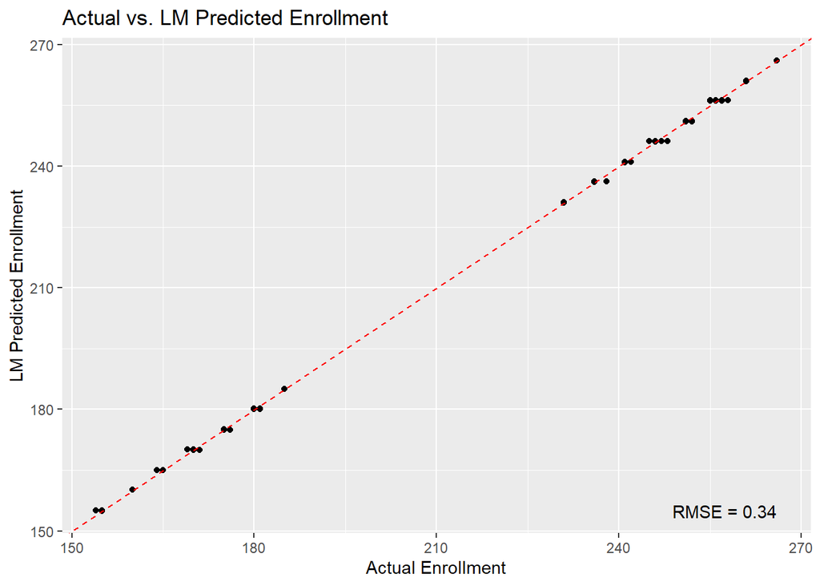

```r
# Create a data frame for plotting
plot_data <- data.frame(
  actual = test_data$enrollment_count,
  predicted = predictions
)

# Create a scatter plot comparing actual and LM predicted values
ggplot(plot_data, aes(x = actual, y = predicted)) +
  geom_point() +
  geom_abline(intercept = 0, slope = 1, color = "red", linetype = "dashed") +
  labs(x = "Actual Enrollment", y = "LM Predicted Enrollment",
       title = "Actual vs. LM Predicted Enrollment") +
  annotate("text", x = max(plot_data$actual), y = min(plot_data$predicted),
           label = paste("RMSE =", round(rmse_lm, 2)), hjust = 1)
```

# Task 7:

## Fit a comparison model to predict how many students will enroll using the data provided. You must include your code.

**Solution To Task 7:**

The Comparison Model is **Support Vector Machine (SVM) Model**. The Support Vector Machine is a powerful and versatile machine learning algorithm used for both classification and regression tasks.

```r
# Fit a Support Vector Machine (SVM) model
svm_model <- svm(enrollment_count ~ ., data = train_data)

# Make predictions using the SVM model
predictions <- predict(svm_model, newdata = test_data)

# Calculate Root Mean Squared Error (RMSE)
rmse_svm <- sqrt(mean((predictions - test_data$enrollment_count)^2))
cat("Root Mean Squared Error (SVM):", rmse_svm, "\n")
```

```
## Root Mean Squared Error (SVM): 2.580707
```

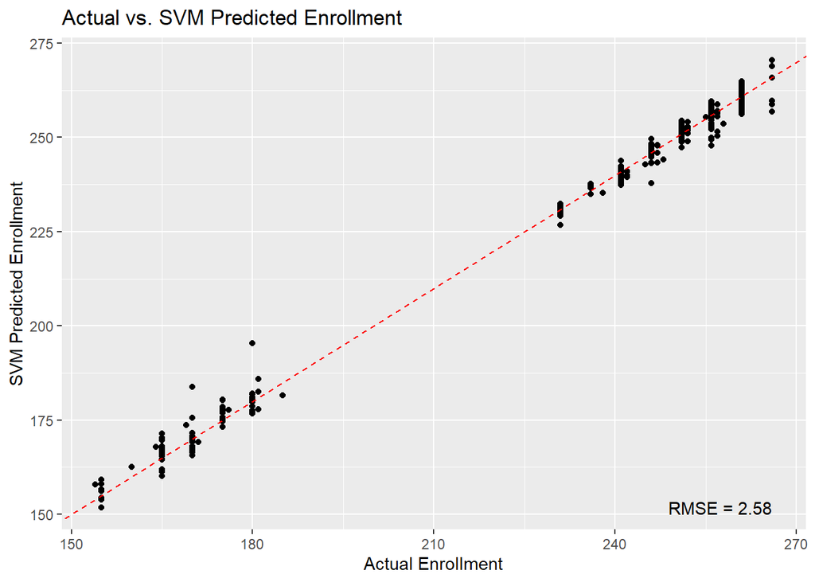

```r
# Create a data frame for plotting
plot_data <- data.frame(
  actual = test_data$enrollment_count,
  predicted = predictions
)

# Create a scatter plot comparing actual and SVM predicted values
ggplot(plot_data, aes(x = actual, y = predicted)) +
  geom_point() +
  geom_abline(intercept = 0, slope = 1, color = "red", linetype = "dashed") +
  labs(x = "Actual Enrollment", y = "SVM Predicted Enrollment",
       title = "Actual vs. SVM Predicted Enrollment") +
  annotate("text", x = max(plot_data$actual), y = min(plot_data$predicted),
           label = paste("RMSE =", round(rmse_svm, 2)), hjust = 1)
```

# Task 8:

## Explain why you chose the two models used in parts 6 and 7.

**Solution To Task 8:**

I chose the **Linear Regression model** as a baseline model because it is simple and efficient to train and interpret. Also, I chose the **Support Vector Machine** because it can efficiently handle non-linear relationships between features and the target variable by using kernel functions and can also transform data into higher-dimensional space.

# Task 9:

## Compare the performance of the two models used in parts 6 and 7, using any method suitable. You must include your code.

**Solution To Task 9:**

I am using **Root Mean Squared Error (RMSE)** to compare the performance of the two model. RMSE take the square root of the Mean Square Error (MSE) to get the RMSE, which provides the average error in the same units as the target variable. I chose this method because it is commonly used and easy to interpret. A lower value means a better model. *Code in Task 6 & 7*.

# Task 10:

## Explain which model performs better and why.

**Solution To Task 10:**

As explain in **Task 9**, a smaller or lower RMSE value indicates that the model has smaller errors in prediction.

Therefore, based on the RMSE results in *Task 6 & 7*, we conclude that the **Linear Regression Model** is performing better at predicting the number of students that will enroll than the **Support Vector Machine Model**.